# BANA 6660 Project 1 Submission

Courtney Baughman / Jamie White / Sayooj Das

October 15, 2015

## **Objective:**

To predict the cost of the policy at a line level for the inputted data set using a regression model. The predicted cost may be for a quote or purchase.

## **About the provided Dataset:**

```r
data = read.csv("C:/Users/sayooj/SkyDrive/Documents/UC Denver/Fall 2015/Predictive Analytics/train_dat1") #read data
dim(data)
```

```
## [1] 332624     19
```

```r
str(data)
```

```
## 'data.frame':    332624 obs. of  19 variables:
##  $ X                : int  636325 572724 22403 471465 598447 558366 9779 154671 468903 106062 ...
##  $ customer_ID      : int  10146233 10131645 10005233 10108421 10137532 10128374 10002271 10035887 10107817 10024585 ...
##  $ shopping_pt      : int  3 2 1 5 1 4 2 1 1 4 ...
##  $ record_type      : int  0 0 0 0 0 0 0 0 0 0 ...
##  $ day              : int  3 0 1 3 2 2 2 0 1 4 ...
##  $ time             : Factor w/ 1134 levels "0:01","0:09",..: 326 460 67 323 229 184 169 306 348 255 ...
##  $ state            : Factor w/ 36 levels "AL","AR","CO",..: 25 3 31 27 32 31 8 32 36 14 ...
##  $ location         : int  10873 13159 13082 15195 11834 14136 11750 10193 11892 13781 ...
##  $ group_size       : int  2 1 1 1 2 2 2 1 1 1 ...
##  $ homeowner        : int  1 0 0 0 0 1 1 1 0 1 ...
##  $ car_age          : int  14 9 11 9 8 10 6 6 6 7 ...
##  $ car_value        : Factor w/ 10 levels "","a","b","c",..: 6 6 5 7 5 7 5 8 7 7 ...
##  $ risk_factor      : int  1 NA NA 2 NA NA NA 4 NA 4 ...
##  $ age_oldest       : int  75 54 54 26 33 45 25 29 21 47 ...
##  $ age_youngest     : int  74 54 54 26 26 38 25 29 21 47 ...
##  $ married_couple   : int  1 0 0 0 1 1 1 0 0 0 ...
##  $ C_previous       : int  3 3 1 4 1 2 1 1 1 1 ...
##  $ duration_previous: int  8 0 1 7 2 1 8 0 5 2 ...
##  $ cost             : int  565 642 664 558 606 605 650 604 622 708 ...
```

*Pairwise correlation matrix:*

The correlation matrix below demonstrates that the correlation between the response variable, cost, and the predictors is extremely low.

```r
cor(data[,c(2,3,4,5,8,9,10,11,13,14,15,16,17,18,19)],use="pairwise",method="spearman")
```

```
##                     customer_ID   shopping_pt   record_type          day
## customer_ID        1.000000e+00 -7.435084e-05 -0.0012335837  0.003054528
## shopping_pt       -7.435084e-05  1.000000e+00  0.4243961405  0.012389759
## record_type       -1.233584e-03  4.243961e-01  1.0000000000  0.033033457
## day                3.054528e-03  1.238976e-02  0.0330334569  1.000000000
## location           4.112126e-02  5.185820e-04  0.0017690040 -0.010024420
## group_size         3.958994e-03  1.066056e-02 -0.0017795105 -0.002940873
## homeowner          6.821580e-04 -1.942890e-02  0.0099745532 -0.005093415
## car_age           -4.868575e-03 -2.026455e-02  0.0019127840  0.005936723
## risk_factor        1.932244e-03 -7.519834e-04 -0.0003686357  0.012899179
## age_oldest         2.264979e-03 -7.425208e-03  0.0036967805 -0.018654095
## age_youngest       6.846186e-04 -1.436735e-02  0.0021516367 -0.020589195
## married_couple     1.297185e-03  1.151194e-02 -0.0001174057 -0.002242384
## C_previous        -4.534736e-03 -3.106254e-03  0.0038782535 -0.010468468
## duration_previous  2.155484e-04 -5.917886e-03  0.0086112618 -0.003629385
## cost              -2.719902e-03  5.037816e-02 -0.0072452180  0.009352375
##                        location    group_size    homeowner       car_age
## customer_ID        0.0411212609  0.0039589941  0.000682158 -0.0048685747
## shopping_pt        0.0005185820  0.0106605571 -0.019428903 -0.0202645465
## record_type        0.0017690040 -0.0017795105  0.009974553  0.0019127840
## day               -0.0100244200 -0.0029408734 -0.005093415  0.0059367226
## location           1.0000000000 -0.0068168871  0.004253913  0.0082092734
## group_size        -0.0068168871  1.0000000000  0.205367117 -0.0417989741
## homeowner          0.0042539128  0.2053671169  1.000000000 -0.0579569887
## car_age            0.0082092734 -0.0417989741 -0.057956989  1.0000000000
## risk_factor        0.0073742565 -0.0628416898 -0.177461057  0.0859024170
## age_oldest         0.0006798713  0.2280444464  0.427462869  0.0061705016
## age_youngest       0.0038029002 -0.0002962033  0.370016980  0.0006340729
## married_couple    -0.0059676553  0.7959445503  0.199114055 -0.0433356951
## C_previous         0.0139160170  0.0797005083  0.114639501 -0.1510079829
## duration_previous  0.0204419157  0.0646637820  0.180032169 -0.0479820774
## cost               0.0035484924 -0.0406779799 -0.219702968 -0.2757646015
##                     risk_factor    age_oldest  age_youngest married_couple
## customer_ID        0.0019322440  0.0022649791  0.0006846186   0.0012971854
## shopping_pt       -0.0007519834 -0.0074252077 -0.0143673550   0.0115119367
## record_type       -0.0003686357  0.0036967805  0.0021516367  -0.0001174057
## day                0.0128991786 -0.0186540953 -0.0205891949  -0.0022423840
## location           0.0073742565  0.0006798713  0.0038029002  -0.0059676553
## group_size        -0.0628416898  0.2280444464 -0.0002962033   0.7959445503
## homeowner         -0.1774610567  0.4274628690  0.3700169797   0.1991140546
```

[output cut: 9 more lines]

```
## customer_ID       -0.004534736      0.0002155484 -0.002719902
## shopping_pt       -0.003106254     -0.0059178858  0.050378156
## record_type        0.003878253      0.0086112618 -0.007245218
## day               -0.010468468     -0.0036293849  0.009352375
## location           0.013916017      0.0204419157  0.003548492
## group_size         0.079700508      0.0646637820 -0.040677980
## homeowner          0.114639501      0.1800321689 -0.219702968
## car_age           -0.151007983     -0.0479820774 -0.275764601
## risk_factor       -0.129811948     -0.1731128789  0.123756851
## age_oldest         0.066275502      0.2527558900 -0.223679507
## age_youngest       0.053563231      0.2252724689 -0.255466441
## married_couple     0.067623127      0.0513883164 -0.075917670
## C_previous         1.000000000      0.1625931633 -0.085460478
## duration_previous  0.162593163      1.0000000000 -0.169677748
## cost              -0.085460478     -0.1696777483  1.000000000
```

The interesting correlations in the matrix were:  
cost-homeowner **(-22%)**  
cost-car_age **(-28%)**  
age_oldest_age_youngest **(90%)**  
cost-age_oldest **(-22%)**  
cost-age_youngest **(-26%)**  
cost-duration_previous **(-17%)**  
risk_factor-homeowner **(-18%)**  
risk_factor-age_oldest **(-30%)**  
risk_factor-age_youngest **(-29%)**  
risk_factor-C_previous **(-13%)**  
risk_factor-duration_previous **(-17%)**

## **Invoke all required libraries**

```r
library(ggplot2)
library(tree)
library(party)
library(dplyr)
```

## **Feature Engineering steps to reduce Overfitting**

*Convert below variables to FACTORS (based on EDA)*

```r
data$X = as.factor(data$X)
data$customer_ID = as.factor(data$customer_ID)
data$shopping_pt = as.factor(data$shopping_pt)
data$record_type = as.factor(data$record_type)
data$day = as.factor(data$day)
data$location = as.factor(data$location)
data$homeowner = as.factor(data$homeowner)
data$risk_factor = as.factor(data$risk_factor) ##in-doubt
data$married_couple = as.factor(data$married_couple)
data$C_previous = as.factor(data$C_previous)
```

*Derived predictors:*

**Weekend:** Variable to determine whether the day of transaction is a weekday or weekend.

```r
data$weekend = as.factor(ifelse(data$day %in% 0:4, "N", "Y"))
```

**Timeframe:** Variable to determine whether the time of transaction is during core business hours.

**Figure-Median Cost by Time:**

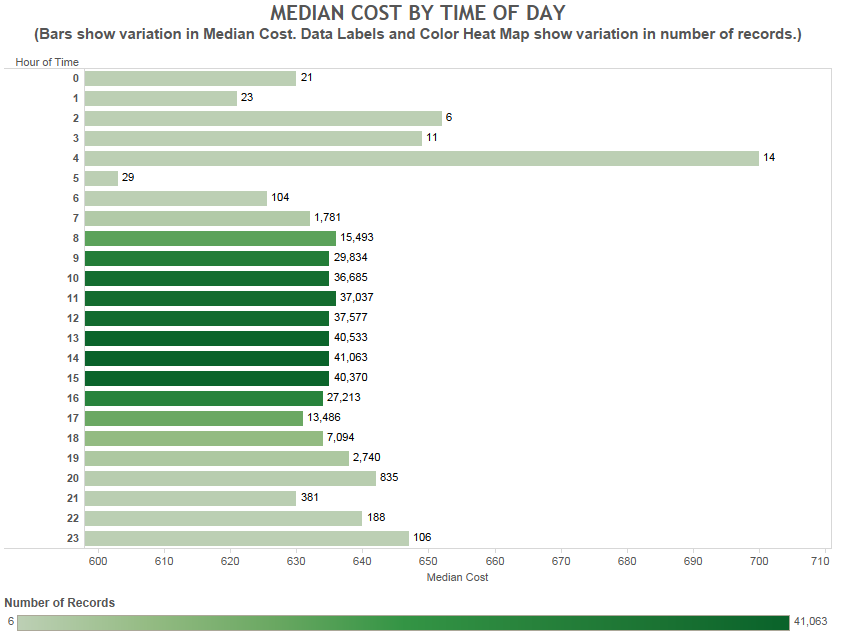

The above visual provided sufficient insight into the need for deriving a new timeframe feature indicating whether the transaction occurred during business hours of 8am through 5pm.

```r
data$HH = as.integer(sub(":.*", "", data$time)) #get the HOUR from TIME and convert to INTEGER
data$timeframe = as.factor(ifelse(data$HH %in% 8:17, "bus_hours","non_bus_hours"))
```

**Group features:** A set of derived flags to determine whether the customer is an individual or group.

```r
data$age_diff = data$age_oldest-data$age_youngest

data$single = as.factor(ifelse(data$age_diff==0 & data$group_size==1,
                                     "Y", "N"))

data$family = as.factor(ifelse(data$group_size >= 2
                                     & data$married_couple==1, "Y", "N"))


data$family_w_kids = as.factor(ifelse(data$group_size > 2
                                            & data$married_couple==1
                                            & data$age_youngest<=21 , "Y", "N"))

#data$single = ifelse(data$single=="Y",1,0)
#data$family = ifelse(data$family=="Y",1,0)
#data$family_w_kids = ifelse(data$family_w_kids=="Y",1,0)
```

**Convert the homeowner indicator:**

```r
data$homeowner = ifelse(data$homeowner=="1","Y","N")
```

**Convert risk factor into a numerical variable:**  
The risk factor is an ordinal number based on the information provided. Converting the risk factor to a discrete numerical variable will aid the model building process as discussed further down below.

```r
data$risk_factor = ifelse(data$risk_factor=="1",1,
                          ifelse(data$risk_factor=="2",2,
                                 ifelse(data$risk_factor=="3",3,
                                        ifelse(data$risk_factor=="4",4,NA))))
```

**Missing value Analysis**

```r
sapply(data, function(x) sum(is.na(x)))
```

```
##                 X       customer_ID       shopping_pt       record_type
##                 0                 0                 0                 0
##               day              time             state          location
##                 0                 0                 0                 0
##        group_size         homeowner           car_age         car_value
##                 0                 0                 0                 0
##       risk_factor        age_oldest      age_youngest    married_couple
##            120291                 0                 0                 0
##        C_previous duration_previous              cost           weekend
##              9366              9366                 0                 0
##                HH         timeframe          age_diff            single
##                 0                 0                 0                 0
##            family     family_w_kids
##                 0                 0
```

*The missing values need to be filled in the dataframe to prevent the model from eliminating such rows. Hence, further EDA work was performed to logically deduce these values instead of arbitrarily filling them with random/average values.*  
*Filling C_Previous:* Adding an extra level - “Unknown” to fill NA values for C_previous. It was also observed that the duration_previous was always an NA when the C_previous was NA, and vice-versa.

```r
levels(data$C_previous) <- c("1", "2", "3", "4", "Unknown")
data$C_previous[is.na(data$C_previous)] = "Unknown"
```

*Filling duration_previous:* Since duration_previous is a column of integer datatype, we replace NA values with “0”. Logically, this means that if the customer never had product option C, the duration would be ZERO years.

```r
data$duration_previous[is.na(data$duration_previous)] = 0
```

*Filling risk_factor:* Per our correlation matrix, the risk factor variable is not highly correlated with any single predictor variable. Considering the risk factor is an ordinal numerical variable, a multiple linear regression model was used to predict the missing values and ROUNDED to the nearest integer. The predictor variables were determined via Exploratory Data Analysis, the visuals of which are as follows:

**Figure-Risk Factor Distribution by State:**

[figure not shown]

**Figure-Risk Factor Distribution by Age:**

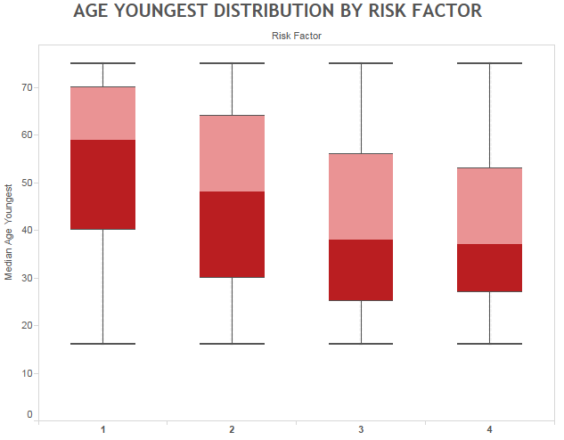

Let us begin by first splitting the dataset in two : records with risk-factor and without risk-factor.

```r
risk <- data[!is.na(data$risk_factor), ]
norisk <- data[is.na(data$risk_factor), ]

hx_tree = ctree(risk$risk_factor ~  risk$state) #Classification tree relating risk factor and state

#plot (hx_tree, main="Classification Tree-Risk Factor vs State",asp=0.5)  # the ctree
```

**Figure-Classification tree Risk Factor by State:**

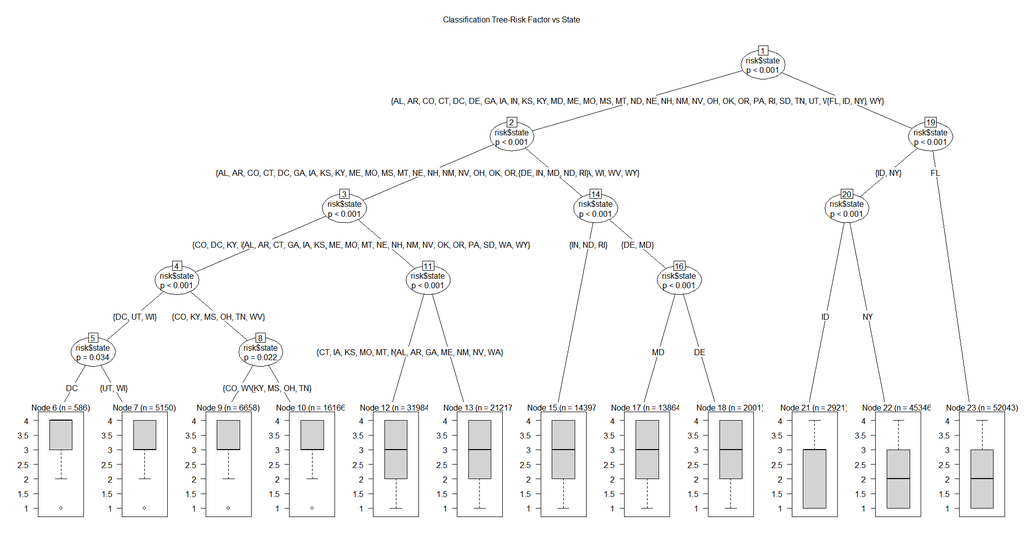

Based on the above classification tree, we can derive a new feature categorizing the states into low, medium and high risk factors.

```r
data$state_cat = ifelse(data$state %in% c("ID","NY","FL"),"l1",
                        ifelse(data$state %in% c("DC","UT","WI","CO","KY","MS","OH","TN"),"l3","l2"))

risk <- data[!is.na(data$risk_factor), ]
norisk <- data[is.na(data$risk_factor), ]

hx_lm = lm(risk_factor ~ family+
                         family_w_kids+
                         age_oldest*age_youngest+
                         state_cat+
                         duration_previous+
                         car_age*car_value+
                         homeowner,data=risk)

summary(hx_lm)
```

```
##
## Call:
## lm(formula = risk_factor ~ family + family_w_kids + age_oldest *
##     age_youngest + state_cat + duration_previous + car_age *
##     car_value + homeowner, data = risk)
##
## Residuals:
##     Min      1Q  Median      3Q     Max
## -2.6937 -0.6501 -0.1000  0.7385  2.7769
##
## Coefficients:
##                           Estimate Std. Error t value Pr(>|t|)
## (Intercept)              2.395e+00  3.529e-01   6.786 1.15e-11 ***
## familyY                  4.378e-02  5.622e-03   7.787 6.91e-15 ***
## family_w_kidsY          -1.350e-01  2.479e-02  -5.445 5.19e-08 ***
## age_oldest               8.484e-03  4.246e-04  19.981  < 2e-16 ***
## age_youngest             2.215e-02  6.212e-04  35.661  < 2e-16 ***
## state_catl2              8.064e-01  4.505e-03 179.017  < 2e-16 ***
## state_catl3              1.000e+00  6.523e-03 153.335  < 2e-16 ***
## duration_previous       -1.807e-02  4.450e-04 -40.618  < 2e-16 ***
## car_age                 -1.903e-02  2.256e-02  -0.843    0.399
## car_valuea               3.295e-02  4.117e-01   0.080    0.936
## car_valueb              -7.743e-01  3.916e-01  -1.978    0.048 *
## car_valuec              -4.075e-01  3.536e-01  -1.152    0.249
## car_valued              -3.677e-01  3.527e-01  -1.043    0.297
## car_valuee              -3.789e-01  3.526e-01  -1.074    0.283
## car_valuef              -3.944e-01  3.527e-01  -1.118    0.263
## car_valueg              -4.374e-01  3.527e-01  -1.240    0.215
## car_valueh              -4.574e-01  3.529e-01  -1.296    0.195
## car_valuei              -3.714e-01  3.546e-01  -1.047    0.295
## homeownerY              -1.451e-01  4.789e-03 -30.302  < 2e-16 ***
## age_oldest:age_youngest -4.687e-04  8.430e-06 -55.605  < 2e-16 ***
## car_age:car_valuea       1.242e-02  2.306e-02   0.538    0.590
## car_age:car_valueb       3.687e-02  2.326e-02   1.585    0.113
## car_age:car_valuec       2.539e-02  2.262e-02   1.123    0.262
## car_age:car_valued       2.315e-02  2.258e-02   1.025    0.305
## car_age:car_valuee       2.435e-02  2.257e-02   1.079    0.281
## car_age:car_valuef       2.917e-02  2.258e-02   1.292    0.196
## car_age:car_valueg       3.240e-02  2.259e-02   1.434    0.152
## car_age:car_valueh       3.254e-02  2.264e-02   1.437    0.151
## car_age:car_valuei       2.388e-02  2.297e-02   1.040    0.298
## ---
## Signif. codes:  0 '***' 0.001 '**' 0.01 '*' 0.05 '.' 0.1 ' ' 1
##
## Residual standard error: 0.9496 on 212304 degrees of freedom
## Multiple R-squared:  0.2693, Adjusted R-squared:  0.2692
## F-statistic:  2795 on 28 and 212304 DF,  p-value: < 2.2e-16
```

```r
fitted.risk_factor = round(predict(hx_lm,newdata=risk),digits = 0)
input.risk_factor = as.character (risk$risk_factor) # actuals
# View(cbind(input.risk_factor,fitted.risk_factor))
mean (input.risk_factor != fitted.risk_factor) # misclassification %
```

```
## [1] 0.6744312
```

### **Populating the missing risk factor in the original dataset**

The linear model, **hx_lm**, was used to fill the missing NA risk factors in the split norisk dataframe.

```r
norisk$risk_factor = round(predict(hx_lm,newdata=norisk))

data_wo_NA = rbind(risk,norisk)

data_wo_NA$shopping_pt = as.numeric(as.character(data_wo_NA$shopping_pt))

dim(data_wo_NA)
```

```
## [1] 332624     27
```

The above dimensions indicate that the combined dataset, **data_wo_NA**, now has the same number of rows as the original. This will be the dataframe for further predictions.

### **Modelling the response - COST**

A multiple linear regression model was selected to predict the cost at a line level. Using a correlation matrix, we selected variables with high correlation with the response variable. Additionally, we performed EDA for the non-numeric variables in Tableau. Below are the plots demonstrating interesting correlations:

**Figure-Cost by weekday/weekend:**

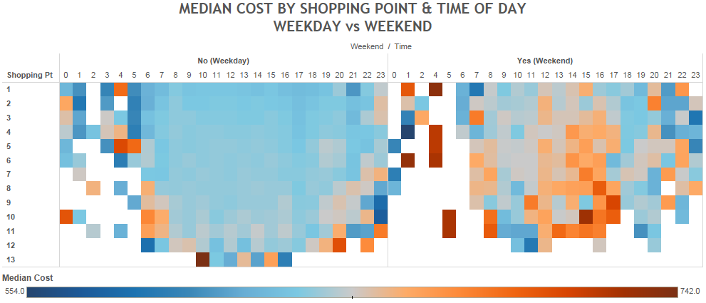

**Figure-Cost by State:**

[figure not shown]

**Figure-Cost by Car Value:**

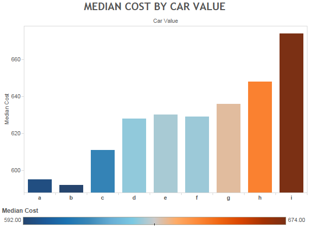

**Figure-Cost by Time of day:**

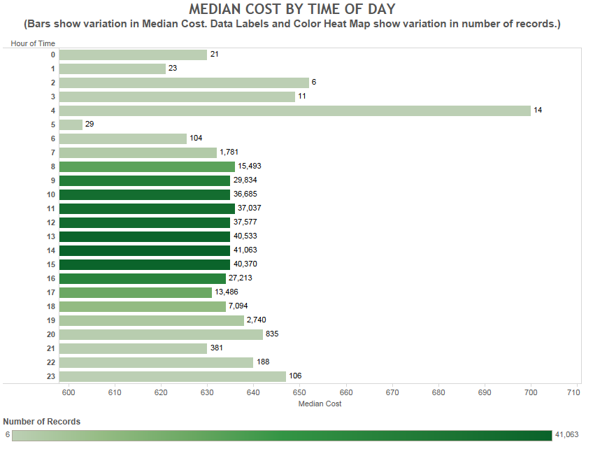

The following multiple linear regression model was chosen to predict the response, **COST**. The EDA demonstrated a very strong interaction between a few features, hence, interaction terms were introduced to improve ability to capture the variability in the response.

```r
lm_cost = lm (cost ~  risk_factor+
                      car_value+
                      car_age*car_value+
                      state+
                      age_oldest+
                      risk_factor*state+
                      risk_factor*homeowner+
                      risk_factor*age_oldest+
                      #risk_factor*age_youngest+
                      risk_factor*family+
                      family+
                      #family*family_w_kids+
                      family*homeowner+
                      timeframe+
                      weekend+
                      duration_previous+
                      #C_previous*duration_previous+
                      car_value*homeowner+
                      shopping_pt+
                      homeowner, data = data_wo_NA)


summary(lm_cost)
```

```
##
## Call:
## lm(formula = cost ~ risk_factor + car_value + car_age * car_value +
##     state + age_oldest + risk_factor * state + risk_factor *
##     homeowner + risk_factor * age_oldest + risk_factor * family +
##     family + family * homeowner + timeframe + weekend + duration_previous +
##     car_value * homeowner + shopping_pt + homeowner, data = data_wo_NA)
##
## Residuals:
##     Min      1Q  Median      3Q     Max
## -362.24  -24.33   -0.96   23.16  233.68
##
## Coefficients:
##                          Estimate Std. Error t value Pr(>|t|)
## (Intercept)            669.363801   7.282180  91.918  < 2e-16 ***
## risk_factor              6.221877   0.579841  10.730  < 2e-16 ***
## car_valuea             -60.000222   9.813905  -6.114 9.74e-10 ***
## car_valueb             -59.492144   9.289136  -6.404 1.51e-10 ***
## car_valuec             -26.946541   7.116686  -3.786 0.000153 ***
## car_valued             -19.980476   7.069813  -2.826 0.004711 **
## car_valuee             -16.984168   7.066364  -2.404 0.016238 *
## car_valuef             -19.184194   7.067974  -2.714 0.006643 **
## car_valueg             -13.093155   7.073335  -1.851 0.064162 .
## car_valueh               0.036312   7.101038   0.005 0.995920
## car_valuei              30.772015   7.350768   4.186 2.84e-05 ***
## car_age                 -0.818222   0.450375  -1.817 0.069255 .
## stateAR                 22.729001   3.349448   6.786 1.16e-11 ***
## stateCO                 12.730650   2.300113   5.535 3.12e-08 ***
## stateCT                 31.920870   2.563024  12.454  < 2e-16 ***
## stateDC                 61.053248   4.973552  12.276  < 2e-16 ***
## stateDE                  8.797511   2.688393   3.272 0.001066 **
## stateFL                 -8.169310   1.670351  -4.891 1.00e-06 ***
## stateGA                 12.296715   2.952461   4.165 3.12e-05 ***
## stateIA                -22.653431   4.622422  -4.901 9.55e-07 ***
## stateID                -29.857577   2.378930 -12.551  < 2e-16 ***
## stateIN                -18.455146   1.896411  -9.732  < 2e-16 ***
## stateKS                 -0.022228   3.738169  -0.006 0.995256
## stateKY                 23.535024   2.741837   8.584  < 2e-16 ***
## stateMD                 11.953293   1.842599   6.487 8.76e-11 ***
## stateME                -19.502006   3.925530  -4.968 6.77e-07 ***
```

[output cut: 76 more lines]

```
## car_valuea:homeownerY   -6.651217   4.390707  -1.515 0.129814
## car_valueb:homeownerY   -1.862891   4.104600  -0.454 0.649934
## car_valuec:homeownerY   -7.669282   2.962213  -2.589 0.009625 **
## car_valued:homeownerY   -5.404629   2.885344  -1.873 0.061051 .
## car_valuee:homeownerY   -6.534481   2.876836  -2.271 0.023123 *
## car_valuef:homeownerY   -8.810613   2.879289  -3.060 0.002214 **
## car_valueg:homeownerY  -10.461824   2.889614  -3.620 0.000294 ***
## car_valueh:homeownerY  -10.228438   2.947537  -3.470 0.000520 ***
## car_valuei:homeownerY  -12.257231   3.487573  -3.515 0.000441 ***
## ---
## Signif. codes:  0 '***' 0.001 '**' 0.01 '*' 0.05 '.' 0.1 ' ' 1
##
## Residual standard error: 37.65 on 332513 degrees of freedom
## Multiple R-squared:  0.3317, Adjusted R-squared:  0.3315
## F-statistic:  1500 on 110 and 332513 DF,  p-value: < 2.2e-16
```

## **Significant Inferences from the model:**

#### *Assuming all other variables remain constant*

1. A higher car value (g,h,i) increases the cost.
2. Cost of the policy may potentially be lower for homeowners.
3. The cost of a policy is higher over the weekend.

## **Predicting Cost Vector for test dataset:**

```r
test_dat1_no_y = read.csv("C:/Users/sayooj/SkyDrive/Documents/UC Denver/Fall 2015/Predictive Analytics/Project1/test_dat1_no_y.csv")

test_data = test_dat1_no_y

dim(test_data)
```

```
## [1] 332625     18
```

### **Feature-engineering for test dataset**

```r
test_data$X = as.factor(test_data$X)
test_data$customer_ID = as.factor(test_data$customer_ID)
test_data$shopping_pt = as.factor(test_data$shopping_pt)
test_data$record_type = as.factor(test_data$record_type)
test_data$day = as.factor(test_data$day)
test_data$location = as.factor(test_data$location)
test_data$homeowner = as.factor(test_data$homeowner)
test_data$risk_factor = as.factor(test_data$risk_factor) ##in-doubt
test_data$married_couple = as.factor(test_data$married_couple)
test_data$C_previous = as.factor(test_data$C_previous)

test_data$weekend = as.factor(ifelse(test_data$day %in% 0:4, "N", "Y"))

test_data$HH = as.integer(sub(":.*", "", test_data$time)) #get the HOUR from TIME and convert to INTEGER
test_data$timeframe = as.factor(ifelse(test_data$HH %in% 8:17, "bus_hours","non_bus_hours"))

test_data$age_diff = test_data$age_oldest-test_data$age_youngest

test_data$single = as.factor(ifelse(test_data$age_diff==0 & test_data$group_size==1,
                                     "Y", "N"))

test_data$family = as.factor(ifelse(test_data$group_size >= 2
                                     & test_data$married_couple==1, "Y", "N"))


test_data$family_w_kids = as.factor(ifelse(test_data$group_size > 2
                                            & test_data$married_couple==1
                                            & test_data$age_youngest<=21 , "Y", "N"))

test_data$homeowner = ifelse(test_data$homeowner=="1","Y","N")

test_data$risk_factor = ifelse(test_data$risk_factor=="1",1,
                          ifelse(test_data$risk_factor=="2",2,
                                 ifelse(test_data$risk_factor=="3",3,
                                        ifelse(test_data$risk_factor=="4",4,NA))))

levels(test_data$C_previous) <- c("1", "2", "3", "4", "Unknown")
test_data$C_previous[is.na(test_data$C_previous)] = "Unknown"
test_data$duration_previous[is.na(test_data$duration_previous)] = 0


test_data$state_cat = ifelse(test_data$state %in% c("ID","NY","FL"),"l1",
                        ifelse(test_data$state %in% c("DC","UT","WI","CO","KY","MS","OH","TN"),"l3","l2"))

test_risk <- test_data[!is.na(test_data$risk_factor), ]
test_norisk <- test_data[is.na(test_data$risk_factor), ]

test_norisk$risk_factor = round(predict(hx_lm,newdata=test_norisk))

test_data_wo_NA = rbind(test_risk,test_norisk)

dim(test_data_wo_NA)
```

```
## [1] 332625     26
```

```r
test_data_wo_NA$shopping_pt = as.numeric(as.character(test_data_wo_NA$shopping_pt))
```

### **Predicting Cost function**

```r
test_data_wo_NA$cost = round(predict(lm_cost,newdata=test_data_wo_NA),digits = 0)
```

### **Export X-Cost dataframe to CSV for submission**

```r
submission_csv = select(test_data_wo_NA,X,cost)

write.csv(submission_csv, file="submission.csv",row.names = FALSE)
```